# Tidying US Census dataset

Farhod Ibragimov

2025-03-04

```r
library(tidyverse)
library(usmap)
library(dplyr)
```

## Tidying dataset

```r
census_data <- read.csv("https://raw.githubusercontent.com/farhodibr/CUNY-SPS-MSDS/refs/heads/main/DATA607/PROJECT2/US_Census_Data.csv")

census_data <- census_data |>
  select(-Fact.Note)
glimpse(census_data)
```

```
## Rows: 85
## Columns: 51
## $ Fact           <chr> "Population estimates, July 1, 2016,  (V2016)", "Popula…
## $ Alabama        <chr> "4,863,300", "4,780,131", "1.70%", "4,779,736", "6.00%"…
## $ Alaska         <chr> "741,894", "710,249", "4.50%", "710,231", "7.30%", "7.6…
## $ Arizona        <chr> "6,931,071", "6,392,301", "8.40%", "6,392,017", "6.30%"…
## $ Arkansas       <chr> "2,988,248", "2,916,025", "2.50%", "2,915,918", "6.40%"…
## $ California     <chr> "39,250,017", "37,254,522", "5.40%", "37,253,956", "6.3…
## $ Colorado       <chr> "5,540,545", "5,029,324", "10.20%", "5,029,196", "6.10%…
## $ Connecticut    <chr> "3,576,452", "3,574,114", "0.10%", "3,574,097", "5.20%"…
## $ Delaware       <chr> "952,065", "897,936", "6.00%", "897,934", "5.80%", "6.2…
## $ Florida        <chr> "20,612,439", "18,804,592", "9.60%", "18,801,310", "5.5…
## $ Georgia        <chr> "10,310,371", "9,688,680", "6.40%", "9,687,653", "6.40%…
## $ Hawaii         <chr> "1,428,557", "1,360,301", "5.00%", "1,360,301", "6.40%"…
## $ Idaho          <chr> "1,683,140", "1,567,650", "7.40%", "1,567,582", "6.80%"…
```

[output cut: 38 more lines]

Why do I think this dataset is not tidy:

- **Multiple variables in one column**:  
  “Fact” column contains several descriptions of the data, which needs to be separate to be tidy
- States supposed to be rows (observations), not columns.
- Each row represents multiple observations. In tidy dataset each row represents single observation, for example a specific state’s demographic data for a single year.

Here I create separate tidy data table for populations of each state in years 2010 and 2016

```r
state_names <- colnames(census_data)[3:ncol(census_data)]
#state_names

population_data <- census_data |>
  filter(Fact %in% c("Population estimates, July 1, 2016,  (V2016)",
                     "Population, Census, April 1, 2010"))

long_population_data <- population_data |>
  pivot_longer(
    cols = -Fact,
    names_to = "state",
    values_to = "population"
  ) |>
  mutate(year = case_when(
    grepl("2016", Fact) ~2016,
    grepl("2010", Fact) ~ 2010,
    TRUE ~ NA_integer_
  )) |>
  select(-Fact) |>
  pivot_wider(
    names_from = year,
    values_from = population
   ) |>
  # |>
  # mutate(
  #   `2010` = as.numeric(`2010`),
  #   `2016` = as.numeric(`2016`)
  # )
  select(state, "2010", "2016")

long_population_data$`2010` <- gsub(",", "", long_population_data$`2010`)
long_population_data$`2010` <-  as.numeric(long_population_data$`2010`)

long_population_data$`2016` <- gsub(",", "", long_population_data$`2016`)
long_population_data$`2016` <-  as.numeric(long_population_data$`2016`)
print(long_population_data)
```

```
## # A tibble: 50 × 3
##    state         `2010`   `2016`
##    <chr>          <dbl>    <dbl>
##  1 Alabama      4779736  4863300
##  2 Alaska        710231   741894
##  3 Arizona      6392017  6931071
##  4 Arkansas     2915918  2988248
##  5 California  37253956 39250017
##  6 Colorado     5029196  5540545
##  7 Connecticut  3574097  3576452
##  8 Delaware      897934   952065
##  9 Florida     18801310 20612439
## 10 Georgia      9687653 10310371
## # ℹ 40 more rows
```

This `long_population_data`data table is tidy and ready for analysis.

In this code I created `create_long_table`function which makes it easier to create different tidy data tables:

```r
create_long_table <- function(column_name, rows) {
  result <- census_data |>
  slice(rows) |>
  pivot_longer(
    cols = !Fact,
    names_to = "state",
    values_to = column_name
  ) |>
   mutate(year = case_when(
    grepl("2016", Fact) ~2016,
    grepl("2010", Fact) ~ 2010,
    TRUE ~ NA_integer_
  )) |>
  select(-Fact) |>
  select(state, year, all_of(column_name)) |>
  mutate(
    !!column_name := round(as.numeric(gsub("%", "", !!sym(column_name))), 2)
    )

  return(result)
}
```

Here I create `gender_table_long`tidy data table which includes female population proportions for each state in years 2010 and 2016. I use `create_long_table`to create this table. Also I did data transformation because some states had proportions in percents, and some decimal values as actual proportions.

```r
gender_table_long <- create_long_table("female_prop", 11:12)
gender_table_long <- gender_table_long |>
  mutate(
    female_prop = if_else(
                          female_prop < 1,
                          round(female_prop * 100, 2),
                          round(female_prop, 2)
  ))
print(gender_table_long)
```

```
## # A tibble: 100 × 3
##    state        year female_prop
##    <chr>       <dbl>       <dbl>
##  1 Alabama      2016        51.6
##  2 Alaska       2016        47.7
##  3 Arizona      2016        50.3
##  4 Arkansas     2016        50.9
##  5 California   2016        50.3
##  6 Colorado     2016        49.7
##  7 Connecticut  2016        51.2
##  8 Delaware     2016        51.6
##  9 Florida      2016        51.1
## 10 Georgia      2016        51.3
## # ℹ 90 more rows
```

This code creates new observations in `gender_table_long` for male population for each state which is better for analysis.

```r
gender_table_long|>
  mutate(
    male_prop = 100 - female_prop
  ) |>
  pivot_longer(
    cols = contains("prop"),
    names_to = "gender",
    values_to = "value"
  ) |>
  pivot_wider(
    names_from = year,
    values_from = value,
    names_prefix = "X"
  ) |>
  select(state, gender, X2010, X2016) |>
  mutate(
    prop_change = X2016 - X2010
  )
```

```
## # A tibble: 100 × 5
##    state      gender      X2010 X2016 prop_change
##    <chr>      <chr>       <dbl> <dbl>       <dbl>
##  1 Alabama    female_prop  51.5  51.6       0.100
##  2 Alabama    male_prop    48.5  48.4      -0.100
##  3 Alaska     female_prop  48    47.7      -0.300
##  4 Alaska     male_prop    52    52.3       0.300
##  5 Arizona    female_prop  50.3  50.3       0
##  6 Arizona    male_prop    49.7  49.7       0
##  7 Arkansas   female_prop  50.9  50.9       0
##  8 Arkansas   male_prop    49.1  49.1       0
##  9 California female_prop  50.3  50.3       0
## 10 California male_prop    49.7  49.7       0
## # ℹ 90 more rows
```

```r
head(gender_table_long)
```

```
## # A tibble: 6 × 3
##   state       year female_prop
##   <chr>      <dbl>       <dbl>
## 1 Alabama     2016        51.6
## 2 Alaska      2016        47.7
## 3 Arizona     2016        50.3
## 4 Arkansas    2016        50.9
## 5 California  2016        50.3
## 6 Colorado    2016        49.7
```

From here I created few data tables for different age ranges:

```r
under_5_proportions_long <- create_long_table("prop_under_5", 5:6) |>
  group_by(year, state)
print(under_5_proportions_long)
```

```
## # A tibble: 100 × 3
## # Groups:   year, state [100]
##    state        year prop_under_5
##    <chr>       <dbl>        <dbl>
##  1 Alabama      2016          6
##  2 Alaska       2016          7.3
##  3 Arizona      2016          6.3
##  4 Arkansas     2016          6.4
##  5 California   2016          6.3
##  6 Colorado     2016          6.1
##  7 Connecticut  2016          5.2
##  8 Delaware     2016          5.8
##  9 Florida      2016          5.5
## 10 Georgia      2016          6.4
## # ℹ 90 more rows
```

```r
under_18_proportions_long <- create_long_table("prop_under_18", 7:8)
print(under_18_proportions_long)
```

```
## # A tibble: 100 × 3
##    state        year prop_under_18
##    <chr>       <dbl>         <dbl>
##  1 Alabama      2016          22.6
##  2 Alaska       2016          25.2
##  3 Arizona      2016          23.5
##  4 Arkansas     2016          23.6
##  5 California   2016          23.2
##  6 Colorado     2016          22.8
##  7 Connecticut  2016          21.1
##  8 Delaware     2016          21.5
##  9 Florida      2016          20.1
## 10 Georgia      2016          24.4
## # ℹ 90 more rows
```

```r
over_65_proportions_long <- create_long_table("over_65", 9:10)
print(over_65_proportions_long)
```

```
## # A tibble: 100 × 3
##    state        year over_65
##    <chr>       <dbl>   <dbl>
##  1 Alabama      2016    16.1
##  2 Alaska       2016    10.4
##  3 Arizona      2016    16.9
##  4 Arkansas     2016    16.3
##  5 California   2016    13.6
##  6 Colorado     2016    13.4
##  7 Connecticut  2016    16.1
##  8 Delaware     2016    17.5
##  9 Florida      2016    19.9
## 10 Georgia      2016    13.1
## # ℹ 90 more rows
```

```r
population_proportions <- under_5_proportions_long |>
  left_join(under_18_proportions_long, by = c("state", "year")) |>
  left_join(over_65_proportions_long, c("state", "year")) |>
  mutate(
    prop_18_to_65 = 100 - prop_under_18 - over_65
  )
```

This code creates data table for population proportions in 18-65 ages range for each state

```r
population_18_65_long <- population_proportions |>
  select(state, year, prop_18_to_65)
print(population_18_65_long)
```

```
## # A tibble: 100 × 3
## # Groups:   year, state [100]
##    state        year prop_18_to_65
##    <chr>       <dbl>         <dbl>
##  1 Alabama      2016          61.3
##  2 Alaska       2016          64.4
##  3 Arizona      2016          59.6
##  4 Arkansas     2016          60.1
##  5 California   2016          63.2
##  6 Colorado     2016          63.8
##  7 Connecticut  2016          62.8
##  8 Delaware     2016          61
##  9 Florida      2016          60
## 10 Georgia      2016          62.5
## # ℹ 90 more rows
```

## Analysis

This plot shows analysis for each state’s population in 2010.

```r
library(usmap)
long_population_data$state <- gsub("\\.", " ", long_population_data$state)

names(long_population_data)[names(long_population_data) == "2010"] <- "pop_2010"
names(long_population_data)[names(long_population_data) == "2016"] <- "pop_2016"

data_for_map <- long_population_data |>
  left_join(usmap::statepop, by = c("state" = "full"))

mismatches <- setdiff(long_population_data$state, usmap::statepop$full)
print(mismatches)
```

```
## character(0)
```

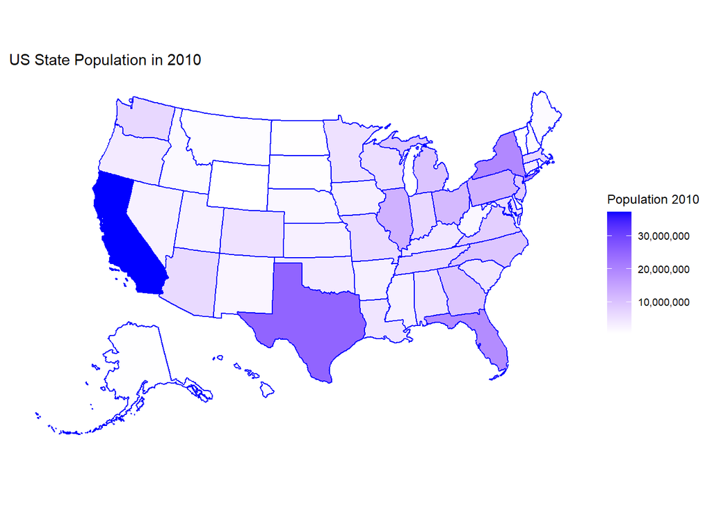

```r
# long_population_data$state <- trimws(long_population_data$state)
# usmap::statepop$full <- trimws(usmap::statepop$full)
# head(data_for_map)
# plot_usmap(data_for_map, values = "pop_2010", color = "blue") +
#   scale_fill_continuous(name = "Population 2010",
#                         low = "white",
#                         high = "blue") +
#   theme(legend.position = "right") +
#   labs(title = "US State Population in 2010")

plot_usmap(data = long_population_data, values = "pop_2010", color = "blue") +
  scale_fill_continuous(name = "Population 2010",
                        low = "white",
                        high = "blue",
                        labels = scales::comma) +
  theme(legend.position = "right") +
  labs(title = "US State Population in 2010")
```

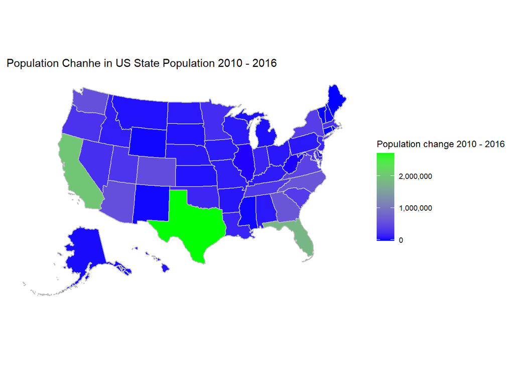

```r
long_population_data <- long_population_data |>
  mutate(
    pop_change = pop_2016 - pop_2010
  )

plot_usmap(data=long_population_data, values = "pop_change", color = "gray") +
  scale_fill_gradient2(name = "Population change 2010 - 2016",
                        low = "red", mid = "blue", high = "green",
                        midpoint = 0,
                        labels = scales::comma
                        ) +
  theme(legend.position = "right") +
  labs(title = "Population Chanhe in US State Population 2010 - 2016")
```

From this plot we see states which had most increases in population:

1. Texas
2. California
3. Florida